# Présentation de l’Analyse du Cancer du Sein

Armand Ayebie

# Introduction

Ce rapport présente une analyse du jeu de données sur le cancer du sein en utilisant un modèle de régression logistique. L’objectif principal est de distinguer entre les tumeurs bénignes et malignes en fonction de diverses caractéristiques. Les sections suivantes détaillent les étapes de prétraitement des données, de formation du modèle et d’évaluation. Le cancer du sein est l’un des cancers les plus fréquents et les plus graves touchant les femmes dans le monde entier. Selon les statistiques de 2015, plus de 2,1 millions de femmes ont été diagnostiquées avec cette maladie, représentant environ 25 % des cas mondiaux de cancer. Le principal défi dans le diagnostic du cancer du sein réside dans la capacité à classifier correctement les tumeurs en deux catégories : bénignes (non cancéreuses) et malignes (cancéreuses). Une classification précise est essentielle pour déterminer le traitement approprié et améliorer les chances de survie des patientes.

# Prétraitement des Données

```r
# Charger les bibliothèques nécessaires
library(tidyverse)
library(caret)
library(e1071)
library(ggplot2)
library(mlbench)
library(randomForest)
library(corrplot)
library(ROCR)
library(pROC)
```

```r
# Charger le jeu de données
cancer <- read.csv("breast-cancer.csv", sep = ",", header = TRUE)
# Nettoyage des données
cancer <- na.omit(cancer)
cancer <- cancer %>% select(-id)
cancer$diagnosis <- as.factor(ifelse(cancer$diagnosis == "M", 1, 0))
```

## Résumé des Données

```r
summary(cancer)
```

```
##  diagnosis  radius_mean      texture_mean   perimeter_mean     area_mean
##  0:357     Min.   : 6.981   Min.   : 9.71   Min.   : 43.79   Min.   : 143.5
##  1:212     1st Qu.:11.700   1st Qu.:16.17   1st Qu.: 75.17   1st Qu.: 420.3
##            Median :13.370   Median :18.84   Median : 86.24   Median : 551.1
##            Mean   :14.127   Mean   :19.29   Mean   : 91.97   Mean   : 654.9
##            3rd Qu.:15.780   3rd Qu.:21.80   3rd Qu.:104.10   3rd Qu.: 782.7
##            Max.   :28.110   Max.   :39.28   Max.   :188.50   Max.   :2501.0
##  smoothness_mean   compactness_mean  concavity_mean    concave.points_mean
##  Min.   :0.05263   Min.   :0.01938   Min.   :0.00000   Min.   :0.00000
##  1st Qu.:0.08637   1st Qu.:0.06492   1st Qu.:0.02956   1st Qu.:0.02031
##  Median :0.09587   Median :0.09263   Median :0.06154   Median :0.03350
##  Mean   :0.09636   Mean   :0.10434   Mean   :0.08880   Mean   :0.04892
##  3rd Qu.:0.10530   3rd Qu.:0.13040   3rd Qu.:0.13070   3rd Qu.:0.07400
##  Max.   :0.16340   Max.   :0.34540   Max.   :0.42680   Max.   :0.20120
##  symmetry_mean    fractal_dimension_mean   radius_se        texture_se
##  Min.   :0.1060   Min.   :0.04996        Min.   :0.1115   Min.   :0.3602
##  1st Qu.:0.1619   1st Qu.:0.05770        1st Qu.:0.2324   1st Qu.:0.8339
##  Median :0.1792   Median :0.06154        Median :0.3242   Median :1.1080
##  Mean   :0.1812   Mean   :0.06280        Mean   :0.4052   Mean   :1.2169
##  3rd Qu.:0.1957   3rd Qu.:0.06612        3rd Qu.:0.4789   3rd Qu.:1.4740
##  Max.   :0.3040   Max.   :0.09744        Max.   :2.8730   Max.   :4.8850
##   perimeter_se       area_se        smoothness_se      compactness_se
##  Min.   : 0.757   Min.   :  6.802   Min.   :0.001713   Min.   :0.002252
##  1st Qu.: 1.606   1st Qu.: 17.850   1st Qu.:0.005169   1st Qu.:0.013080
##  Median : 2.287   Median : 24.530   Median :0.006380   Median :0.020450
##  Mean   : 2.866   Mean   : 40.337   Mean   :0.007041   Mean   :0.025478
##  3rd Qu.: 3.357   3rd Qu.: 45.190   3rd Qu.:0.008146   3rd Qu.:0.032450
##  Max.   :21.980   Max.   :542.200   Max.   :0.031130   Max.   :0.135400
##   concavity_se     concave.points_se   symmetry_se       fractal_dimension_se
##  Min.   :0.00000   Min.   :0.000000   Min.   :0.007882   Min.   :0.0008948
##  1st Qu.:0.01509   1st Qu.:0.007638   1st Qu.:0.015160   1st Qu.:0.0022480
##  Median :0.02589   Median :0.010930   Median :0.018730   Median :0.0031870
##  Mean   :0.03189   Mean   :0.011796   Mean   :0.020542   Mean   :0.0037949
##  3rd Qu.:0.04205   3rd Qu.:0.014710   3rd Qu.:0.023480   3rd Qu.:0.0045580
##  Max.   :0.39600   Max.   :0.052790   Max.   :0.078950   Max.   :0.0298400
##   radius_worst   texture_worst   perimeter_worst    area_worst
##  Min.   : 7.93   Min.   :12.02   Min.   : 50.41   Min.   : 185.2
##  1st Qu.:13.01   1st Qu.:21.08   1st Qu.: 84.11   1st Qu.: 515.3
##  Median :14.97   Median :25.41   Median : 97.66   Median : 686.5
##  Mean   :16.27   Mean   :25.68   Mean   :107.26   Mean   : 880.6
##  3rd Qu.:18.79   3rd Qu.:29.72   3rd Qu.:125.40   3rd Qu.:1084.0
##  Max.   :36.04   Max.   :49.54   Max.   :251.20   Max.   :4254.0
##  smoothness_worst  compactness_worst concavity_worst  concave.points_worst
##  Min.   :0.07117   Min.   :0.02729   Min.   :0.0000   Min.   :0.00000
##  1st Qu.:0.11660   1st Qu.:0.14720   1st Qu.:0.1145   1st Qu.:0.06493
##  Median :0.13130   Median :0.21190   Median :0.2267   Median :0.09993
##  Mean   :0.13237   Mean   :0.25427   Mean   :0.2722   Mean   :0.11461
##  3rd Qu.:0.14600   3rd Qu.:0.33910   3rd Qu.:0.3829   3rd Qu.:0.16140
##  Max.   :0.22260   Max.   :1.05800   Max.   :1.2520   Max.   :0.29100
##  symmetry_worst   fractal_dimension_worst
##  Min.   :0.1565   Min.   :0.05504
##  1st Qu.:0.2504   1st Qu.:0.07146
##  Median :0.2822   Median :0.08004
##  Mean   :0.2901   Mean   :0.08395
##  3rd Qu.:0.3179   3rd Qu.:0.09208
##  Max.   :0.6638   Max.   :0.20750
```

```r
str(cancer)
```

```
## 'data.frame':    569 obs. of  31 variables:
##  $ diagnosis              : Factor w/ 2 levels "0","1": 2 2 2 2 2 2 2 2 2 2 ...
##  $ radius_mean            : num  18 20.6 19.7 11.4 20.3 ...
##  $ texture_mean           : num  10.4 17.8 21.2 20.4 14.3 ...
##  $ perimeter_mean         : num  122.8 132.9 130 77.6 135.1 ...
##  $ area_mean              : num  1001 1326 1203 386 1297 ...
##  $ smoothness_mean        : num  0.1184 0.0847 0.1096 0.1425 0.1003 ...
##  $ compactness_mean       : num  0.2776 0.0786 0.1599 0.2839 0.1328 ...
##  $ concavity_mean         : num  0.3001 0.0869 0.1974 0.2414 0.198 ...
##  $ concave.points_mean    : num  0.1471 0.0702 0.1279 0.1052 0.1043 ...
##  $ symmetry_mean          : num  0.242 0.181 0.207 0.26 0.181 ...
##  $ fractal_dimension_mean : num  0.0787 0.0567 0.06 0.0974 0.0588 ...
##  $ radius_se              : num  1.095 0.543 0.746 0.496 0.757 ...
##  $ texture_se             : num  0.905 0.734 0.787 1.156 0.781 ...
##  $ perimeter_se           : num  8.59 3.4 4.58 3.44 5.44 ...
```

[output cut: 17 more lines]

```r
head(cancer)
```

|  | diagnosis | radius_mean | texture_mean | perimeter_mean | area_mean | smoothness_mean | compactness_mean | concavity_mean | concave.points_mean | symmetry_mean | fractal_dimension_mean | radius_se | texture_se | perimeter_se | area_se | smoothness_se | compactness_se | concavity_se | concave.points_se | symmetry_se | fractal_dimension_se | radius_worst | texture_worst | perimeter_worst | area_worst | smoothness_worst | compactness_worst | concavity_worst | concave.points_worst | … |
| --- | --- | --- | --- | --- | --- | --- | --- | --- | --- | --- | --- | --- | --- | --- | --- | --- | --- | --- | --- | --- | --- | --- | --- | --- | --- | --- | --- | --- | --- | --- |
| 1 | 1 | 17.99 | 10.38 | 122.80 | 1001.0 | 0.11840 | 0.27760 | 0.3001 | 0.14710 | 0.2419 | 0.07871 | 1.0950 | 0.9053 | 8.589 | 153.40 | 0.006399 | 0.04904 | 0.05373 | 0.01587 | 0.03003 | 0.006193 | 25.38 | 17.33 | 184.60 | 2019.0 | 0.1622 | 0.6656 | 0.7119 | 0.2654 | … |
| 2 | 1 | 20.57 | 17.77 | 132.90 | 1326.0 | 0.08474 | 0.07864 | 0.0869 | 0.07017 | 0.1812 | 0.05667 | 0.5435 | 0.7339 | 3.398 | 74.08 | 0.005225 | 0.01308 | 0.01860 | 0.01340 | 0.01389 | 0.003532 | 24.99 | 23.41 | 158.80 | 1956.0 | 0.1238 | 0.1866 | 0.2416 | 0.1860 | … |
| 3 | 1 | 19.69 | 21.25 | 130.00 | 1203.0 | 0.10960 | 0.15990 | 0.1974 | 0.12790 | 0.2069 | 0.05999 | 0.7456 | 0.7869 | 4.585 | 94.03 | 0.006150 | 0.04006 | 0.03832 | 0.02058 | 0.02250 | 0.004571 | 23.57 | 25.53 | 152.50 | 1709.0 | 0.1444 | 0.4245 | 0.4504 | 0.2430 | … |
| 4 | 1 | 11.42 | 20.38 | 77.58 | 386.1 | 0.14250 | 0.28390 | 0.2414 | 0.10520 | 0.2597 | 0.09744 | 0.4956 | 1.1560 | 3.445 | 27.23 | 0.009110 | 0.07458 | 0.05661 | 0.01867 | 0.05963 | 0.009208 | 14.91 | 26.50 | 98.87 | 567.7 | 0.2098 | 0.8663 | 0.6869 | 0.2575 | … |
| 5 | 1 | 20.29 | 14.34 | 135.10 | 1297.0 | 0.10030 | 0.13280 | 0.1980 | 0.10430 | 0.1809 | 0.05883 | 0.7572 | 0.7813 | 5.438 | 94.44 | 0.011490 | 0.02461 | 0.05688 | 0.01885 | 0.01756 | 0.005115 | 22.54 | 16.67 | 152.20 | 1575.0 | 0.1374 | 0.2050 | 0.4000 | 0.1625 | … |
| 6 | 1 | 12.45 | 15.70 | 82.57 | 477.1 | 0.12780 | 0.17000 | 0.1578 | 0.08089 | 0.2087 | 0.07613 | 0.3345 | 0.8902 | 2.217 | 27.19 | 0.007510 | 0.03345 | 0.03672 | 0.01137 | 0.02165 | 0.005082 | 15.47 | 23.75 | 103.40 | 741.6 | 0.1791 | 0.5249 | 0.5355 | 0.1741 | … |

## Visualisation des Données

### Matrice de Corrélation

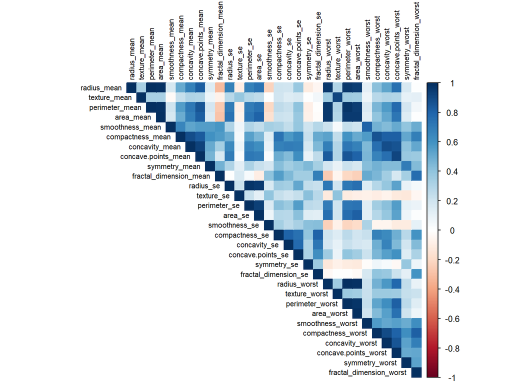

```r
# Matrice de corrélation pour les variables numériques
cor_matrix <- cor(cancer[, sapply(cancer, is.numeric)], use = "complete.obs")
corrplot(cor_matrix, method = "color", type = "upper", tl.cex = 0.7, tl.col = "black")
```

### Distribution du Diagnostic

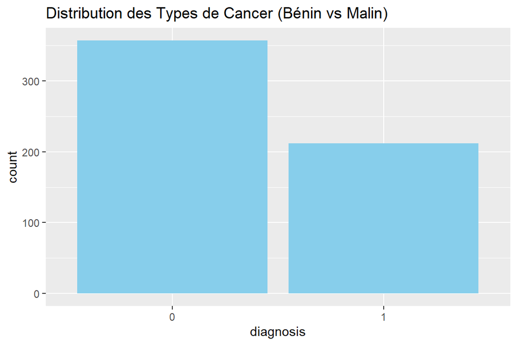

```r
ggplot(cancer, aes(x = diagnosis)) +
  geom_bar(fill = "skyblue") +
  ggtitle("Distribution des Types de Cancer (Bénin vs Malin)")
```

### Taille de la Tumeur vs Texture

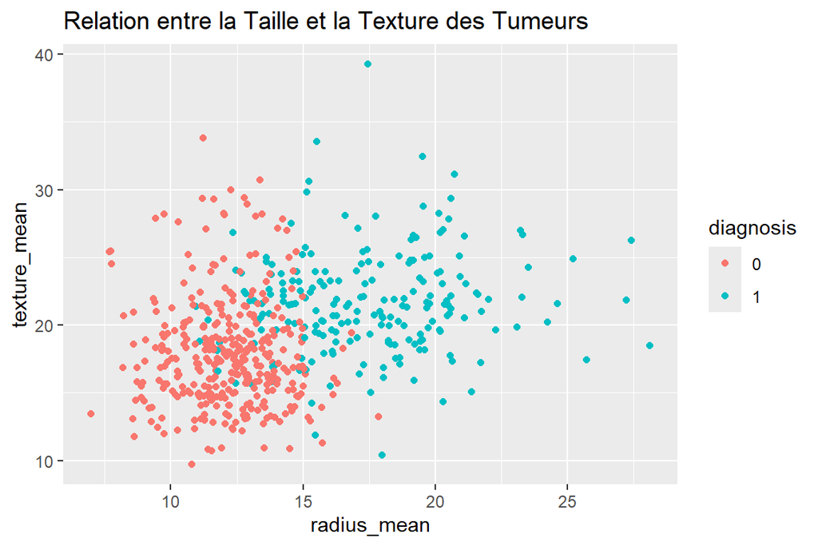

```r
ggplot(cancer, aes(x = radius_mean, y = texture_mean, color = diagnosis)) +
  geom_point() +
  ggtitle("Relation entre la Taille et la Texture des Tumeurs")
```

# Entraînement du Modèle

Nous avons entraîné un modèle de régression logistique pour classifier les tumeurs en fonction des caractéristiques disponibles.

## Séparation des Données

```r
# Division des données en ensembles d'entraînement et de test (80% - 20%)
set.seed(123)
index <- createDataPartition(cancer$diagnosis, p = 0.8, list = FALSE)
train_cancer <- cancer[index, ]
test_cancer <- cancer[-index, ]
dim(train_cancer)
```

```
## [1] 456  31
```

```r
dim(test_cancer)
```

```
## [1] 113  31
```

## Construction du Modèle

```r
# Construction du modèle de régression logistique
model <- glm(diagnosis ~ ., data = train_cancer, family = binomial)
summary(model)
```

```
##
## Call:
## glm(formula = diagnosis ~ ., family = binomial, data = train_cancer)
##
## Coefficients:
##                           Estimate Std. Error z value Pr(>|z|)
## (Intercept)              1.129e+03  1.029e+06   0.001    0.999
## radius_mean             -1.300e+03  4.606e+05  -0.003    0.998
## texture_mean             6.622e+00  1.613e+04   0.000    1.000
## perimeter_mean           1.029e+02  3.786e+04   0.003    0.998
## area_mean                5.885e+00  2.423e+03   0.002    0.998
## smoothness_mean          4.153e+03  3.179e+06   0.001    0.999
## compactness_mean        -1.020e+04  1.164e+06  -0.009    0.993
## concavity_mean           3.570e+03  2.227e+06   0.002    0.999
## concave.points_mean      7.030e+03  2.216e+06   0.003    0.997
## symmetry_mean           -2.598e+03  1.702e+06  -0.002    0.999
## fractal_dimension_mean  -1.465e+04  2.506e+06  -0.006    0.995
## radius_se                3.632e+03  7.558e+05   0.005    0.996
## texture_se              -8.703e+01  7.765e+04  -0.001    0.999
## perimeter_se            -2.869e+02  1.521e+05  -0.002    0.998
## area_se                 -1.224e+01  6.329e+03  -0.002    0.998
## smoothness_se           -2.602e+04  9.401e+06  -0.003    0.998
## compactness_se           7.408e+03  1.135e+07   0.001    0.999
## concavity_se            -3.901e+03  4.313e+06  -0.001    0.999
## concave.points_se        7.431e+04  4.175e+06   0.018    0.986
## symmetry_se             -8.332e+00  9.497e+06   0.000    1.000
## fractal_dimension_se    -1.800e+05  1.490e+07  -0.012    0.990
## radius_worst             3.859e+01  8.160e+04   0.000    1.000
## texture_worst            2.371e+01  1.408e+04   0.002    0.999
## perimeter_worst          1.084e+01  1.418e+04   0.001    0.999
## area_worst               5.280e-01  1.106e+03   0.000    1.000
## smoothness_worst        -2.053e+03  1.094e+06  -0.002    0.999
## compactness_worst       -8.936e+02  1.736e+06  -0.001    1.000
## concavity_worst          6.031e+02  1.042e+06   0.001    1.000
## concave.points_worst    -2.343e+02  7.334e+05   0.000    1.000
## symmetry_worst           2.439e+03  1.181e+06   0.002    0.998
## fractal_dimension_worst  2.443e+04  3.205e+06   0.008    0.994
##
## (Dispersion parameter for binomial family taken to be 1)
##
##     Null deviance: 6.0231e+02  on 455  degrees of freedom
## Residual deviance: 2.3078e-06  on 425  degrees of freedom
## AIC: 62
##
## Number of Fisher Scoring iterations: 25
```